# R基础绘图

## 图形分布

有时候我们需要把不同的图形放到一张图里面，做一个组合图进行比较分析，那么在作图之前就需要把画布进行区域划分，R语言划分函数有两个：par()函数和layout()函数。这两个函数都可以将画布进行绘图区域划分；par()函数将图形均匀地划分成几个区域，layout()函数则可以调整划分的比例。

### par()函数

par()函数的参数，把不同的图放到一起，预先设定图形分割成几块。

```r
par(mfcol = c(2,3), #mfcol按列排列，mfrow按行排列，c(2,3)两行三列
    mar = c(2,2,2,2), #margin c(botton, left, top, right) 设置边距
    bg = 'gray')  #backgroud，设置背景颜色
```

### layout()函数

layout()函数可以调整划分的比例，有的子图包含更多的信息，所占空间更大，通过layout()函数就可以实现画布比例的调整。

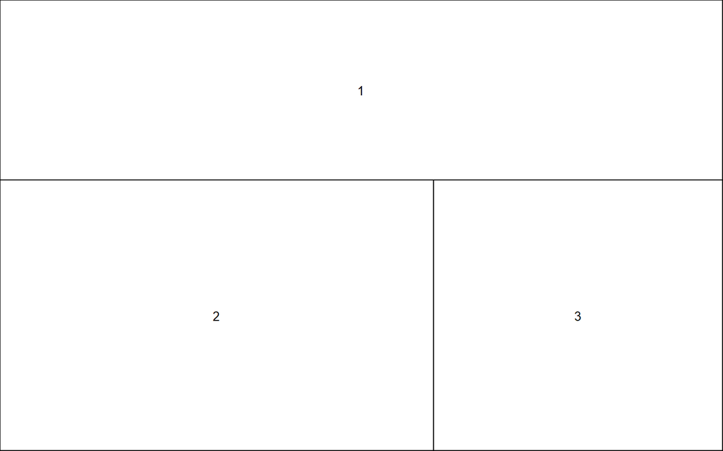

```r
lay <- layout(matrix(c(1,1,2,3), 2, 2, byrow = TRUE),
              # 2, 2划分为两行两列，byrow = TRUE按行顺数，
              # (1,1,2,3)第一行第一、二列为第一幅图，第二行第一列为第二幅图，第二行第二列为第三幅图
              widths = c(3,2), heights = c(2,3)) #widths = c(3,2)设置第一列比第二列比例为3:2
layout.show(lay) #展示划分结果
```

## 泛型函数：plot()

R中最普通的作图函数就是plot()函数，它是一个泛型函数，可以接受很多不同类的对象作为它的作图对象参数；我们这里要解释的是其中的图形参数，而非作图对象参数。可以绘制散点图，折线图。

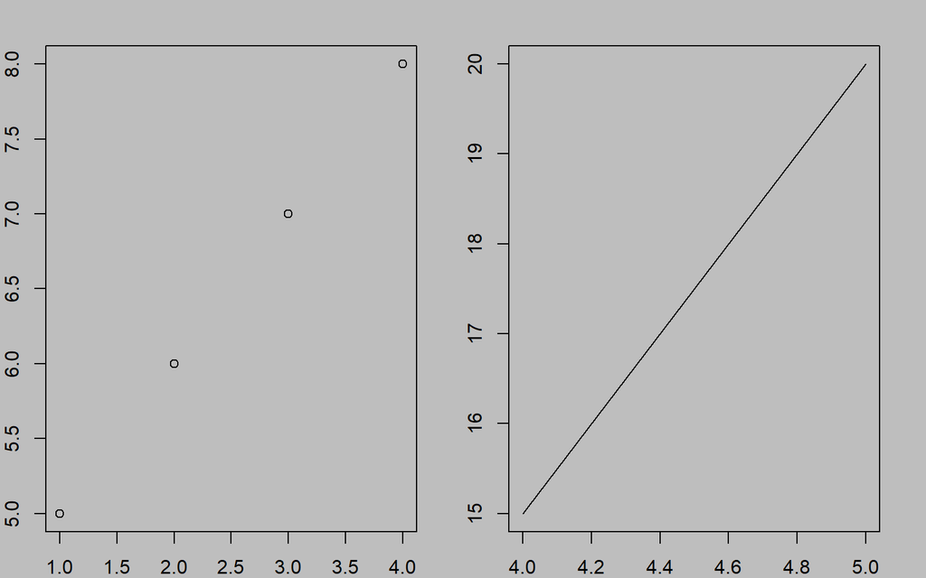

```r
par(mfcol = c(1,2),
    mar = c(2,2,2,2),
    bg = 'gray')
plot(1:4,5:8) #散点图
plot(c(4,5),c(15,20),type='l') #折线图
```

我们先来看看plot()的参数有哪些，先通过一张图有一个大概了解。我们用R自带的数据包mtcars来绘图展示一下：

```r
mtcars #R自带的数据集，32辆汽车的样本信息,包括它们的重量,燃油效率,速度等
```

```
##                      mpg cyl  disp  hp drat    wt  qsec vs am gear carb
## Mazda RX4           21.0   6 160.0 110 3.90 2.620 16.46  0  1    4    4
## Mazda RX4 Wag       21.0   6 160.0 110 3.90 2.875 17.02  0  1    4    4
## Datsun 710          22.8   4 108.0  93 3.85 2.320 18.61  1  1    4    1
## Hornet 4 Drive      21.4   6 258.0 110 3.08 3.215 19.44  1  0    3    1
## Hornet Sportabout   18.7   8 360.0 175 3.15 3.440 17.02  0  0    3    2
## Valiant             18.1   6 225.0 105 2.76 3.460 20.22  1  0    3    1
## Duster 360          14.3   8 360.0 245 3.21 3.570 15.84  0  0    3    4
## Merc 240D           24.4   4 146.7  62 3.69 3.190 20.00  1  0    4    2
## Merc 230            22.8   4 140.8  95 3.92 3.150 22.90  1  0    4    2
## Merc 280            19.2   6 167.6 123 3.92 3.440 18.30  1  0    4    4
## Merc 280C           17.8   6 167.6 123 3.92 3.440 18.90  1  0    4    4
## Merc 450SE          16.4   8 275.8 180 3.07 4.070 17.40  0  0    3    3
## Merc 450SL          17.3   8 275.8 180 3.07 3.730 17.60  0  0    3    3
## Merc 450SLC         15.2   8 275.8 180 3.07 3.780 18.00  0  0    3    3
## Cadillac Fleetwood  10.4   8 472.0 205 2.93 5.250 17.98  0  0    3    4
## Lincoln Continental 10.4   8 460.0 215 3.00 5.424 17.82  0  0    3    4
## Chrysler Imperial   14.7   8 440.0 230 3.23 5.345 17.42  0  0    3    4
## Fiat 128            32.4   4  78.7  66 4.08 2.200 19.47  1  1    4    1
## Honda Civic         30.4   4  75.7  52 4.93 1.615 18.52  1  1    4    2
## Toyota Corolla      33.9   4  71.1  65 4.22 1.835 19.90  1  1    4    1
## Toyota Corona       21.5   4 120.1  97 3.70 2.465 20.01  1  0    3    1
## Dodge Challenger    15.5   8 318.0 150 2.76 3.520 16.87  0  0    3    2
## AMC Javelin         15.2   8 304.0 150 3.15 3.435 17.30  0  0    3    2
## Camaro Z28          13.3   8 350.0 245 3.73 3.840 15.41  0  0    3    4
## Pontiac Firebird    19.2   8 400.0 175 3.08 3.845 17.05  0  0    3    2
## Fiat X1-9           27.3   4  79.0  66 4.08 1.935 18.90  1  1    4    1
## Porsche 914-2       26.0   4 120.3  91 4.43 2.140 16.70  0  1    5    2
## Lotus Europa        30.4   4  95.1 113 3.77 1.513 16.90  1  1    5    2
## Ford Pantera L      15.8   8 351.0 264 4.22 3.170 14.50  0  1    5    4
## Ferrari Dino        19.7   6 145.0 175 3.62 2.770 15.50  0  1    5    6
## Maserati Bora       15.0   8 301.0 335 3.54 3.570 14.60  0  1    5    8
## Volvo 142E          21.4   4 121.0 109 4.11 2.780 18.60  1  1    4    2
```

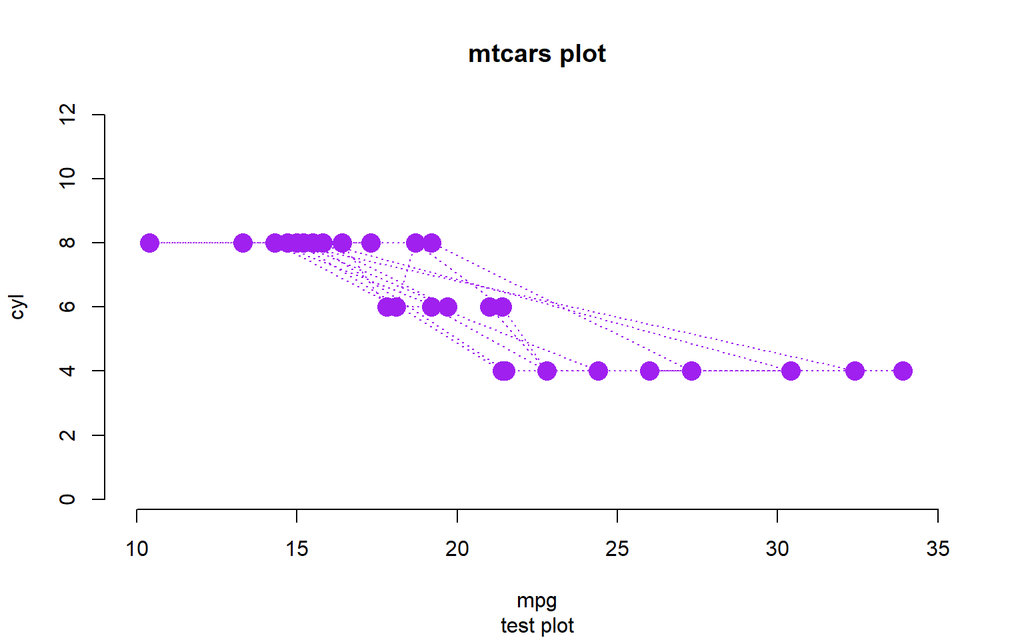

```r
plot(mtcars[,1:2],
     type = 'o', #线的类型
     pch = 16, #点的图形
     col = 'purple', #颜色
     lty = 3, #线的属性
     asp = 1, #图形纵横比y/x
     main = 'mtcars plot', #主标题
     sub = 'test plot', #副标题
     cex = 2, #点的大小
     xlim = c(10,35), #x范围
     ylim = c(4,8), #y范围
     frame = F) #边框的有无
```

对plot()的参数type、pch进一步解释：

type 图形样式类型，有九种可能的取值，分别代表不同的样式。：’p’⇒画点；’l’⇒画线5；’b’⇒同时画点和线，但点线不相交；’c’⇒ 将type=’b’中的点去掉，只剩下相应的线条部分；’o’⇒同时画点和线，且相互重叠，这是它与type = ’b’的区别；’h’⇒画铅垂线；’s’⇒画阶梯线，从一点到下一点时，先画水平线，再画垂直线；’S’⇒也是画阶梯线，但从一点到下一点是先画垂直线，再画水平线；’n’⇒作一幅空图，没有任何内容，但坐标轴、标题等其它元素都照样显示 （除非用别的设置特意隐藏了）。

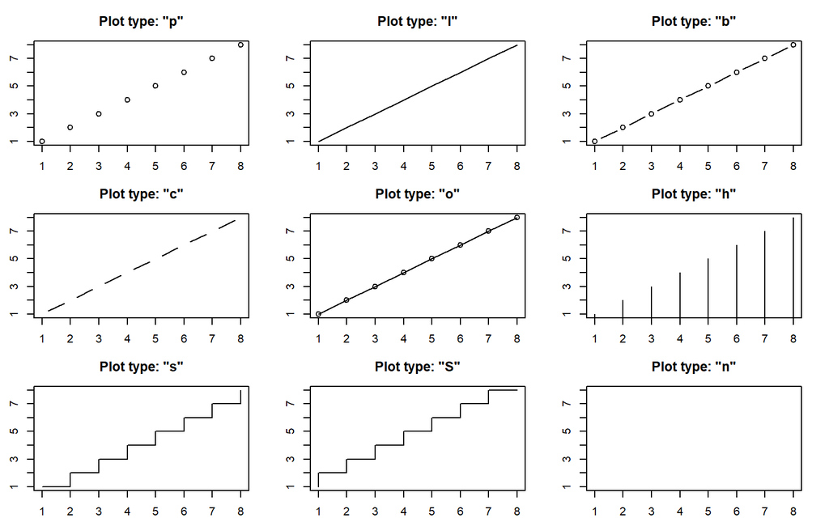

```r
par(mfrow = c(3, 3), mar = c(2, 2.5, 3, 2))
for (i in c("p", "l", "b", "c", "o", "h", "s", "S","n")) {
  plot(c(1:4, 5:8), type = i, main = paste("Plot type: \"",
                                           i, "\"", sep = ""), xlab = "")}
```

点、线、点线（不相接）、擦掉点的线、点线（相接）、垂线、阶梯（水平起步）、阶梯（垂直起步）、无

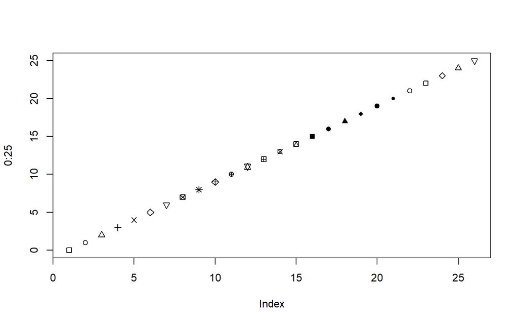

```r
plot(0:25, pch = 0:25)
```

## 作图常用元素

任何一幅统计图形都是由最基础的图形元素构成的，这些元素我们并不陌生，无非就是颜色、点、线（直线、曲线、线段甚至箭头）、矩形、任意多边形、文本以及图例。R提供了相应的一系列函数，用以向已有的图形中添加图形元素。事实上，R的所有作图函数分为两类，一类是高层函数（high-level），用以生成新的图形，另一类就是低层函数（low-level），这 一类指的正是绘制图形元素的这些基础函数。

### 波动线lines()

在添加元素之前，先画一个框架，指定坐标轴范围 ，再向图中添加元素

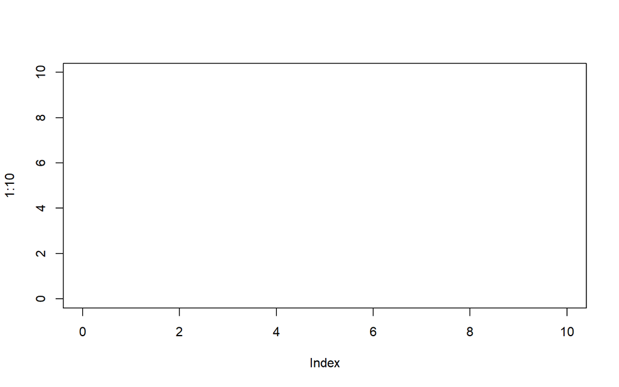

```r
plot(1:10, type = "n", xlim = c(0, 10), ylim = c(0,10))
```

向图中添加10个正态随机数绝对值的波动线

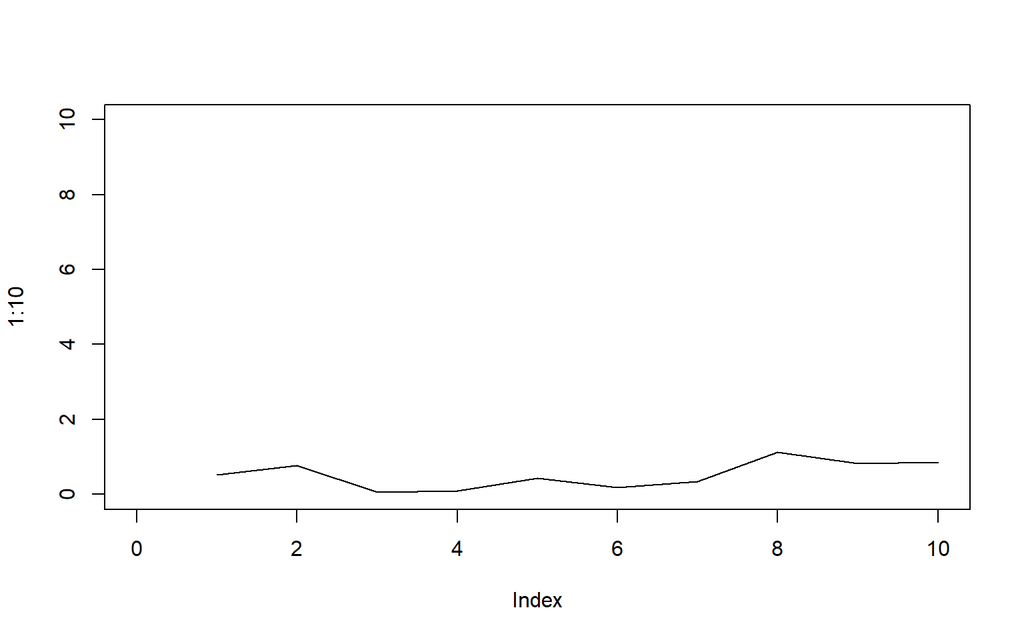

```r
plot(1:10, type = "n", xlim = c(0, 10), ylim = c(0,10))
lines(1:10, abs(rnorm(10)))
```

### 直线abline()

向图中添加不同的直线，y=b*x+a,x=2,y=2

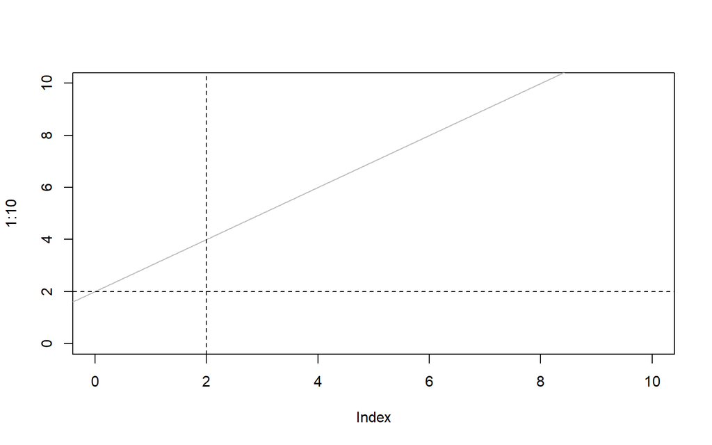

```r
plot(1:10, type = "n", xlim = c(0, 10), ylim = c(0,10))
abline(a = 2, b = 1, col = "gray") #y=b*x+a
abline(v = 2, lty = 2) #x=2，vertical
abline(h = 2, lty = 2) #y=2，horizontal
```